# Exploring Variables

Scales, Data Types and Distributions

Prof. Dr. Nicolas Meseth

## Overview

- Loading Data from CSV
- Scales of Measurement
- Data Types in R
- Nominal Scale
- Ordinal Scale
- Interval Scale
- Ratio Scale

# Loading Data from CSV

## With `{readr}`

The `readr` package provides functions to read data from text files.

```r
survey <- read_csv("data/mds12_schoko_milch.csv")
```

## A Look at the Result

```r
survey
```

```
# A tibble: 2,811 × 813
   q001hheinkauf q002geburt q003land q004geschlecht q005os v041nofleisch
           <dbl>      <dbl>    <dbl>          <dbl>  <dbl>         <dbl>
 1             2       1970        1              1      0             0
 2             1       1990        7              1      0             0
 3             2       1963        6              1      0             0
 4             2       1989       13              2      0             1
 5             2       1965        4              1      0             1
 6             2       1957        2              1      0             0
 7             2       1960       14              2      0             1
 8             2       1984       13              1      0             0
 9             2       1974        1              2      0             0
10             2       1954       13              2      0             0
# ℹ 2,801 more rows
# ℹ 807 more variables: v041nofleisch_other <chr>, v041diaet_0nodiaet <dbl>,
#   v041diaet_1lowcarb <dbl>, v041diaet_2laktose <dbl>,
#   v041diaet_3gluten <dbl>, v041diaet_4paleo <dbl>, v041diaet_5ketogen <dbl>,
#   v041diaet_6rohkost <dbl>, v041diaet_7makro <dbl>, v041diaet_8trenn <dbl>,
#   v041diaet_9frutarisch <dbl>, v041diaet_10fleisch <dbl>,
#   v041diaet_11mediterran <dbl>, v041diaet_12histaminarm <dbl>, …
```

## Data Representation in R

[figure not shown]

## Dimensions of the Data

Number of observations and variables:

```r
dim(survey)
```

```
[1] 2811  813
```

```r
num_cols <- ncol(survey)
num_rows <- nrow(survey)

print(str_glue("The data set has {num_rows} rows and {num_cols} columns."))
```

```
The data set has 2811 rows and 813 columns.
```

## Adding an ID Column

If there is no ID, we can add a surrogate ID:

```r
survey <- survey |>
  rowid_to_column("id")
```

# Scales of Measurement

## Four Scales of Measurement

[figure not shown]

Read more on scales of measurement in Döring (2023), chapter 8.4

## Types of Variables

[figure not shown]

See Huntington-Klein (2026), chapter 3

# Data Types in R

## Overview of Data Types

| Type | Description | Example |
| --- | --- | --- |
| `<chr>` | String of characters | `"hello"` |
| `<int>` | Whole number | `42L` |
| `<dbl>` | Decimal number | `3.14` |
| `<lgl>` | Boolean value | `TRUE` or `FALSE` |
| `<fct>` | Fixed set of values | `male`, `female`, `diverse` |

## Finding the Data Type

```r
survey |>
    glimpse()
```

```
Rows: 2,811
Columns: 814
$ id                               <int> 1, 2, 3, 4, 5, 6, 7, 8, 9, 10, 11, 12…
$ q001hheinkauf                    <dbl> 2, 1, 2, 2, 2, 2, 2, 2, 2, 2, 2, 1, 2…
$ q002geburt                       <dbl> 1970, 1990, 1963, 1989, 1965, 1957, 1…
$ q003land                         <dbl> 1, 7, 6, 13, 4, 2, 14, 13, 1, 13, 5, …
$ q004geschlecht                   <dbl> 1, 1, 1, 2, 1, 1, 2, 1, 2, 2, 1, 1, 1…
$ q005os                           <dbl> 0, 0, 0, 0, 0, 0, 0, 0, 0, 0, 0, 0, 0…
$ v041nofleisch                    <dbl> 0, 0, 0, 1, 1, 0, 1, 0, 0, 0, 0, 0, 0…
$ v041nofleisch_other              <chr> NA, NA, NA, NA, NA, NA, NA, NA, NA, N…
$ v041diaet_0nodiaet               <dbl> 1, 0, 1, 1, 1, 0, 0, 0, 1, 1, 1, 1, 1…
$ v041diaet_1lowcarb               <dbl> 0, 0, 0, 0, 0, 0, 0, 1, 0, 0, 0, 0, 0…
$ v041diaet_2laktose               <dbl> 0, 0, 0, 0, 0, 0, 0, 0, 0, 0, 0, 0, 0…
$ v041diaet_3gluten                <dbl> 0, 1, 0, 0, 0, 0, 0, 1, 0, 0, 0, 0, 0…
$ v041diaet_4paleo                 <dbl> 0, 0, 0, 0, 0, 0, 0, 0, 0, 0, 0, 0, 0…
```

[output cut: 801 more lines]

## Selecting by Data Type

```r
survey |>
    select(where(is.character)) |>
    names()
```

```
 [1] "v041nofleisch_other"   "v041diaet_other"       "v008ort_other"
 [4] "m071ungestuetzt"       "m072gestuetzt_other"   "m074hafercontra_other"
 [7] "d037schule_other"      "d046miete_other"       "s051krit1_2"
[10] "s051krit1_3"           "s051krit1_4"           "s051krit1_6"
[13] "s051krit1_7"           "s055ungestuetzt"       "s056gestuetzt_other"
[16] "s061info_other"        "Q002altergru4f"        "Q004geschlechtf"
[19] "AX010midiff7f"         "AXpreis5f"             "AD015p1reaktion4f"
[22] "AB1619pvonw2f"         "AX020pgarbor5f"        "AX024labeldiff20f"
[25] "AX027kaufalpro5f"      "AX028kaufpommer8f"     "AXspezial9f"
[28] "V041nofleischf"        "D042hhzahlf"           "D044stadtf"
[31] "AB050anlass2f"         "AB051krit2f"           "S053grund2"
[34] "AB054kaufritter2f"     "AB063anlass2f"         "AB064krit2f"
[37] "AB065kaufmilch2f"      "AB066packdiff2f"       "AB067midiff2f"
[40] "AB068wdiff2f"          "AC070handeldiff3f"
```

# Nominal Scale

## Nominal Scale Overview

Categorical variables without a natural order.

- **Possible interpretations**: Two values are the same or different
- **Examples**: gender, religion, political affiliation
- **Data Type**: convert to `<fct>`

## Converting to Factor

Nominal variables often come as character strings. We can convert them to factors:

```r
survey |>
  select(q004geschlecht) |>
  mutate(q004geschlecht = as_factor(q004geschlecht))
```

```
# A tibble: 2,811 × 1
   q004geschlecht
   <fct>
 1 1
 2 1
 3 1
 4 2
 5 1
 6 1
 7 2
 8 1
 9 2
10 2
# ℹ 2,801 more rows
```

## Recoding Values

We can recode the values to something more meaningful:

```r
s_q004 <-
    survey |>
        select(q004geschlecht) |>
        mutate(q004geschlecht =
            as_factor(q004geschlecht) |>
            fct_recode(
                "männlich" = "1",
                "weiblich" = "2",
                "divers" = "3"
            )
        )

s_q004 |> head(5)
```

```
# A tibble: 5 × 1
  q004geschlecht
  <fct>
1 männlich
2 männlich
3 männlich
4 weiblich
5 männlich
```

## Frequencies of Nominal Variables

```r
s_q004 |>
    count(q004geschlecht)
```

```
# A tibble: 3 × 2
  q004geschlecht     n
  <fct>          <int>
1 männlich        1328
2 weiblich        1481
3 divers             2
```

## Using a Bar Plot

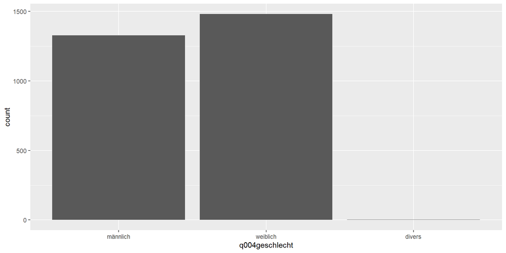

```r
s_q004 |>
    ggplot() +
    aes(x = q004geschlecht) +
    geom_bar()
```

## Order by Frequency

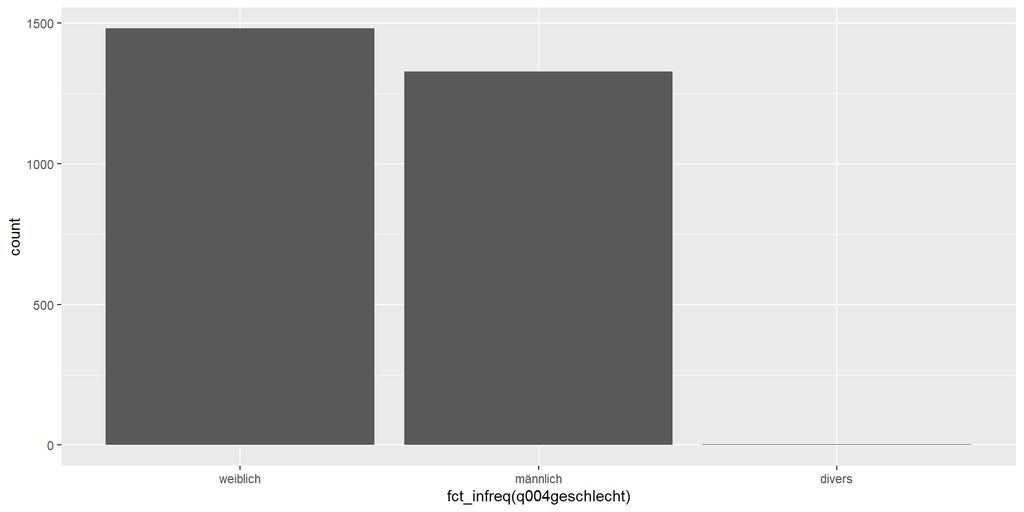

```r
s_q004 |>
    ggplot() +
    aes(x = fct_infreq(q004geschlecht)) +
    geom_bar()
```

## Multiple Nominal Variables

Define a vector of variable names:

```r
locations_labels <- c(
  "v008ort_1discount" = "Discounter",
  "v008ort_2super" = "Supermarkt",
  "v008ort_3sbmarkt" = "SB-Markt",
  "v008ort_4fach" = "Fachgeschäft",
  "v008ort_5markt" = "Wochenmarkt",
  "v008ort_6hof" = "Hofladen",
  "v008ort_7bioladen" = "Bioladen",
  "v008ort_8onlineds" = "Online (Lieferdienst)",
  "v008ort_9online" = "Online (Shop)",
  "v008ort_other" = "Sonstiges"
)
```

## Multiple Nominal Variables

We can access the label of a variable:

```r
locations_labels["v008ort_1discount"]
```

```
v008ort_1discount
     "Discounter"
```

## Multiple Nominal Variables

Get all variables belonging to question 8…

```r
survey |>
  select(id, contains("008"))
```

## Multiple Nominal Variables

But not the “other” variable…

```r
survey |>
  select(id, contains("008"), -v008ort_other)
```

## Multiple Nominal Variables

Make the data long for easier analysis…

```r
survey |>
  select(id, contains("008"), -v008ort_other) |>
  pivot_longer(
      cols = c(everything(), -id),
      names_to = "location",
      values_to = "mentioned"
  )
```

## Multiple Nominal Variables

Convert to factor using the labels…

```r
survey |>
  select(id, contains("008"), -v008ort_other) |>
  pivot_longer(
      cols = c(everything(), -id),
      names_to = "location",
      values_to = "mentioned"
  ) |>
  mutate(location = as_factor(locations_labels[location]))
```

## Multiple Nominal Variables

Filter only the mentioned locations…

```r
survey |>
  select(id, contains("008"), -v008ort_other) |>
  pivot_longer(
      cols = c(everything(), -id),
      names_to = "location",
      values_to = "mentioned"
  ) |>
  mutate(location = as_factor(locations_labels[location])) |>
  filter(mentioned == 1)
```

## Multiple Nominal Variables

Count how often each location was mentioned…

```r
survey |>
  select(id, contains("008"), -v008ort_other) |>
  pivot_longer(
      cols = c(everything(), -id),
      names_to = "location",
      values_to = "mentioned"
  ) |>
  mutate(location = as_factor(locations_labels[location])) |>
  filter(mentioned == 1) |>
  count(location)
```

## Multiple Nominal Variables

Finally, calculate relative frequencies…

```r
survey |>
  select(id, contains("008"), -v008ort_other) |>
  pivot_longer(
      cols = c(everything(), -id),
      names_to = "location",
      values_to = "mentioned"
  ) |>
  mutate(location = as_factor(locations_labels[location])) |>
  filter(mentioned == 1) |>
  count(location) |>
  mutate(anteil = n / num_rows) |>
  head(3)
```

```
# A tibble: 3 × 3
  location       n anteil
  <fct>      <int>  <dbl>
1 Discounter  2065  0.735
2 Supermarkt  2134  0.759
3 SB-Markt     848  0.302
```

## Multiple Nominal Variables

Store this in a new tibble…

```r
s_q008_agg <- survey |>
  select(id, contains("008"), -v008ort_other) |>
  pivot_longer(
      cols = c(everything(), -id),
      names_to = "location",
      values_to = "mentioned"
  ) |>
  mutate(location = as_factor(locations_labels[location])) |>
  filter(mentioned == 1) |>
  count(location) |>
  mutate(anteil = n / num_rows)
```

## Multiple Nominal Variables

And visualize it…

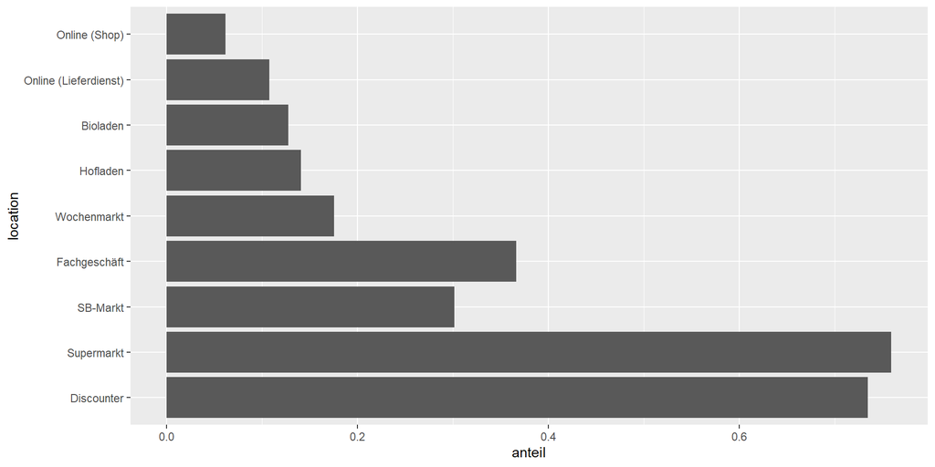

```r
s_q008_agg  |>
  ggplot() +
  aes(y = location, x = anteil) +
  geom_col()
```

## Multiple Nominal Variables

Order the bars by frequencies…

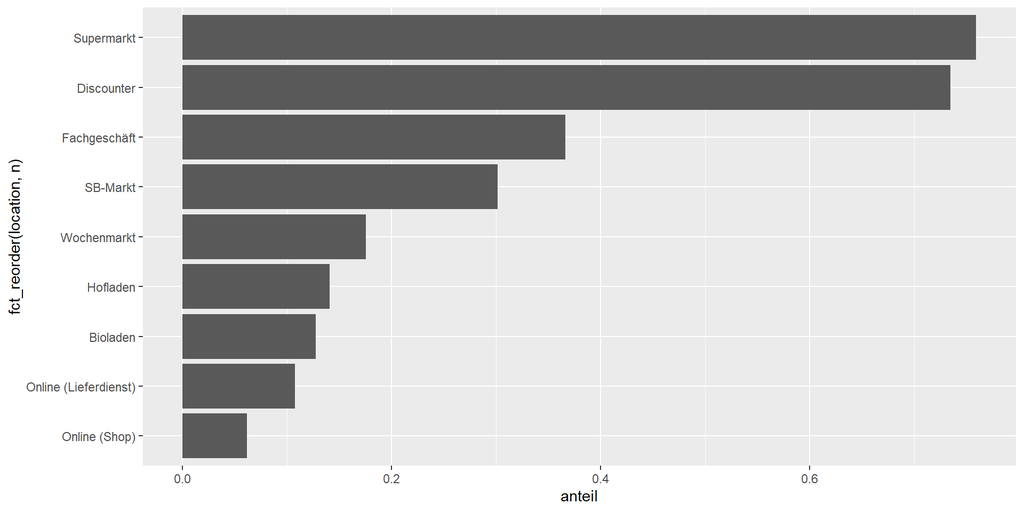

```r
s_q008_agg  |>
  ggplot() +
  aes(y = fct_reorder(location, n), x = anteil) +
  geom_col()
```

## Multiple Nominal Variables

Add a nice label to the x-axis with percentages…

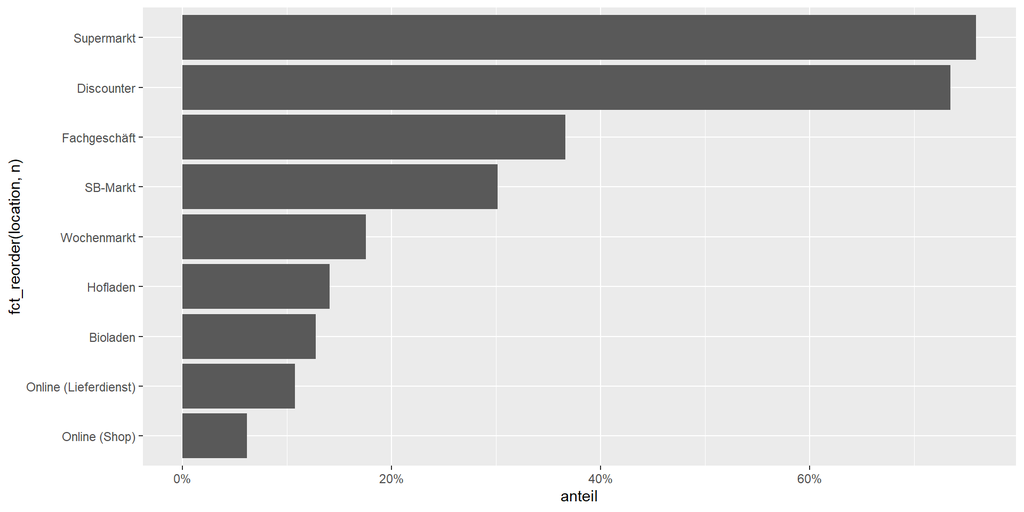

```r
s_q008_agg  |>
  ggplot() +
  aes(y = fct_reorder(location, n), x = anteil) +
  geom_col() +
  scale_x_continuous(labels = scales::percent_format())
```

## Multiple Nominal Variables

Add a header and axis labels…

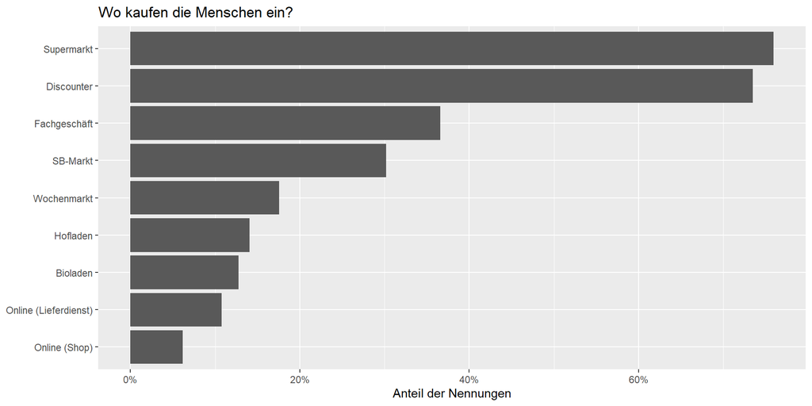

```r
s_q008_agg  |>
  ggplot() +
  aes(y = fct_reorder(location, n), x = anteil) +
  geom_col() +
  scale_x_continuous(labels = scales::percent_format()) +
  labs(title = "Wo kaufen die Menschen ein?", x = "Anteil der Nennungen", y = NULL)
```

## Multiple Nominal Variables

Use a lighter theme…

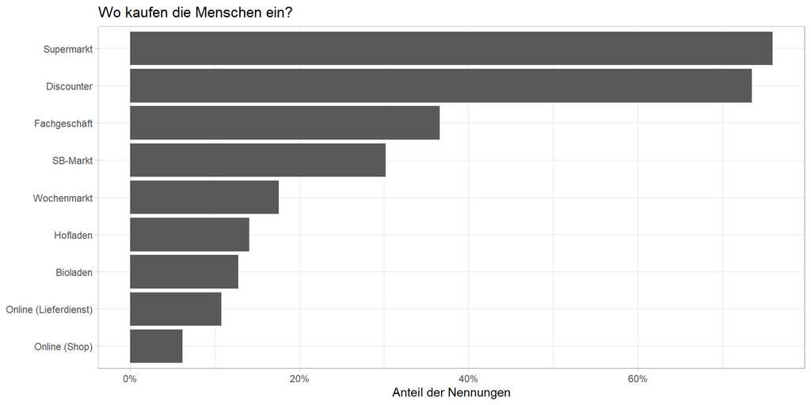

```r
s_q008_agg  |>
  ggplot() +
  aes(y = fct_reorder(location, n), x = anteil) +
  geom_col() +
  scale_x_continuous(labels = scales::percent_format()) +
  labs(title = "Wo kaufen die Menschen ein?", x = "Anteil der Nennungen", y = NULL) +
  theme_light()
```

# Ordinal Scale

## Ordinal Scale Overview

Categorical variables with a natural order, but no fixed intervals.

- **Possible interpretations**: One value is greater than another value
- **Examples**: school grades, satisfaction ratings, t-shirt sizes
- **Data Type**: convert to `<fct>` (ordered)

## Multiple Choice Answers

Get all variables belonging to question 11:

```r
survey |>
  select(id, contains("011"))
```

```
# A tibble: 2,811 × 10
      id p011regio_1wirtschaft p011regio_2vertrauen p011regio_3preis
   <int>                 <dbl>                <dbl>            <dbl>
 1     1                    -2                   -1               -2
 2     2                    -1                    1                0
 3     3                     2                    2                2
 4     4                     1                    1                1
 5     5                     1                    1               -2
 6     6                     0                    1               -1
 7     7                     2                    1                1
 8     8                     2                    2                0
 9     9                     1                    2                1
10    10                     1                    2                0
# ℹ 2,801 more rows
# ℹ 6 more variables: p011regio_4umwelt <dbl>, p011regio_5tierschutz <dbl>,
#   p011regio_6teuer <dbl>, p011regio_7noherkunft <dbl>, p011regio_8bio <dbl>,
#   p011regio_9regional <dbl>
```

This works if the data collection was designed thoughtfully.

## Ordered Factors

“Ich habe ein höheres Vertrauen in regionale Lebensmittel”

```r
s_q011_vertrauen <- survey |>
    select(p011regio_2vertrauen) |>
    mutate(p011regio_2vertrauen =
        as_factor(p011regio_2vertrauen) |>
        fct_recode(
            "trifft nicht zu" = "-2",
            "trifft eher nicht zu" = "-1",
            "teils-teils" = "0",
            "trifft eher zu" = "1",
            "trifft voll zu" = "2"
        ) |>
        fct_relevel("trifft nicht zu", "trifft eher nicht zu", "teils-teils", "trifft eher zu", "trifft voll zu")
    )
```

## Frequencies of Ordinal Variables

Automatically ordered by the factor levels:

```r
s_q011_vertrauen |>
    count(p011regio_2vertrauen)
```

```
# A tibble: 6 × 2
  p011regio_2vertrauen     n
  <fct>                <int>
1 trifft nicht zu        105
2 trifft eher nicht zu   224
3 teils-teils            881
4 trifft eher zu        1083
5 trifft voll zu         510
6 <NA>                     8
```

## Using a Bar Plot

No need to order the bars manually:

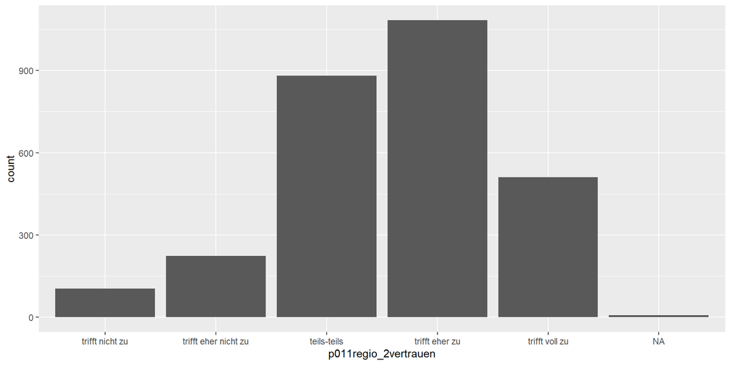

```r
s_q011_vertrauen |>
    ggplot() +
    aes(x = p011regio_2vertrauen) +
    geom_bar()
```

# Interval Scale

## Interval Scale Overview

Ordered values with fixed intervals, but no true zero point.

- **Possible interpretations**: The difference between two values is the same (or not) as the difference between two other values
- **Examples**: temperature in Celsius or Fahrenheit, calendar years
- **Data Type**: `<int>` or `<dbl>`

## Year of Birth

```r
s_q002birthyear <-
  survey |>
  select(q002geburt) |>
  mutate(q002geburt = as.integer(q002geburt))

s_q002birthyear |>
    head(5)
```

```
# A tibble: 5 × 1
  q002geburt
       <int>
1       1970
2       1990
3       1963
4       1989
5       1965
```

## Summary Statistics

```r
s_q002birthyear |>
    drop_na() |>
    summarise(
        min = min(q002geburt),
        q25 = quantile(q002geburt, 0.25),
        median = median(q002geburt),
        q75 = quantile(q002geburt, 0.75),
        max = max(q002geburt),
        mean = mean(q002geburt)
    )
```

```
# A tibble: 1 × 6
    min   q25 median   q75   max  mean
  <int> <dbl>  <int> <dbl> <int> <dbl>
1  1945  1965   1975  1989  2007 1977.
```

## With `skimr`

Get info as a tibble:

```r
library(skimr)
s_q002birthyear |>
  skim(q002geburt) |>
  as_tibble() |>
  clean_names()
```

```
# A tibble: 1 × 12
  skim_type skim_variable n_missing complete_rate numeric_mean numeric_sd
  <chr>     <chr>             <int>         <dbl>        <dbl>      <dbl>
1 numeric   q002geburt            0             1        1977.       14.7
# ℹ 6 more variables: numeric_p0 <dbl>, numeric_p25 <dbl>, numeric_p50 <dbl>,
#   numeric_p75 <dbl>, numeric_p100 <dbl>, numeric_hist <chr>
```

## With `summarytools`

Only for quick info in the console:

```r
library(summarytools)
s_q002birthyear |>
  dfSummary()
```

```
Data Frame Summary
s_q002birthyear
Dimensions: 2811 x 1
Duplicates: 2750

-------------------------------------------------------------------------------------------------------------
No   Variable     Stats / Values              Freqs (% of Valid)   Graph                 Valid      Missing
---- ------------ --------------------------- -------------------- --------------------- ---------- ---------
1    q002geburt   Mean (sd) : 1976.6 (14.7)   61 distinct values         : .             2811       0
     [integer]    min < med < max:                                     : : : . :   :     (100.0%)   (0.0%)
                  1945 < 1975 < 2007                                 . : : : : : : :
                  IQR (CV) : 24 (0)                                  : : : : : : : : .
                                                                   . : : : : : : : : :
-------------------------------------------------------------------------------------------------------------
```

## Histogram

Distribution of birth years:

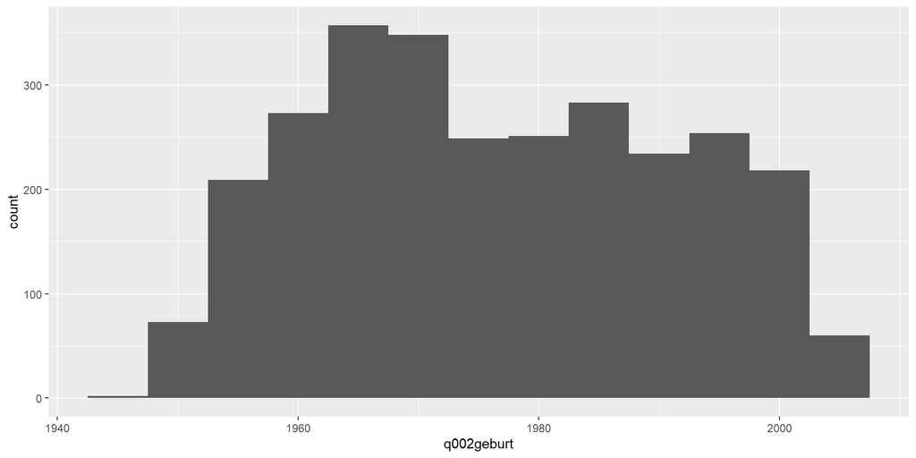

```r
s_q002birthyear |>
    ggplot() +
    aes(x = q002geburt) +
    geom_histogram(binwidth = 5)
```

## Boxplot

Distribution of birth years with a different focus:

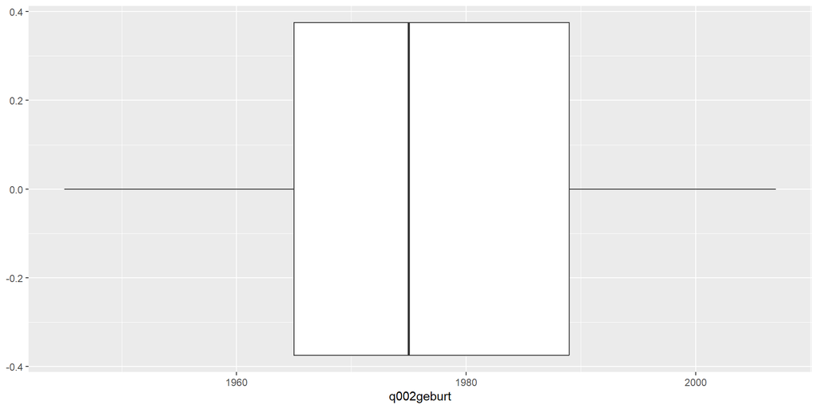

```r
s_q002birthyear |>
    ggplot() +
    aes(x = q002geburt) +
    geom_boxplot()
```

# Ratio Scale

## Ratio Scale Overview

Ordered values with fixed intervals and a true zero point.

- **Possible interpretations**: The ratio of two values is meaningful (e.g., one value is twice as much as another)
- **Examples**: weight, height, income, age
- **Data Type**: `<int>` or `<dbl>`

## Accepted Price

“Geben Sie [..] bitte den Preis an, den Sie für angemessen halten und bei dem Sie zugreifen würden!”

```r
s_q013_accepted_price <- survey |>
    select(u013pzahl_1weihen) |>
    transmute(accepted_price = as.double(u013pzahl_1weihen))

s_q013_accepted_price |>
    drop_na() |>
    head(5)
```

```
# A tibble: 5 × 1
  accepted_price
           <dbl>
1           1.49
2         150
3           1.19
4           3
5           2
```

## Summary Statistics

Look at the mean (!)

```r
s_q013_accepted_price |>
    drop_na() |>
    summarise(
        min = min(accepted_price),
        q25 = quantile(accepted_price, 0.25),
        median = median(accepted_price),
        q75 = quantile(accepted_price, 0.75),
        max = max(accepted_price),
        mean = mean(accepted_price)
    )
```

```
# A tibble: 1 × 6
    min   q25 median   q75   max  mean
  <dbl> <dbl>  <dbl> <dbl> <dbl> <dbl>
1     0   1.2   1.49   1.8   150  4.58
```

## Ratios Become Meaningful

How much more or less is the respondent willing to pay compared to the median?

```r
s_q013_accepted_price |>
    drop_na() |>
    mutate(
        median_price = median(accepted_price),
        ratio_to_median = accepted_price / median_price * 100,
        above_median = accepted_price > median_price
    ) |>
    head(5)
```

```
# A tibble: 5 × 4
  accepted_price median_price ratio_to_median above_median
           <dbl>        <dbl>           <dbl> <lgl>
1           1.49         1.49           100   FALSE
2         150            1.49         10067.  TRUE
3           1.19         1.49            79.9 FALSE
4           3            1.49           201.  TRUE
5           2            1.49           134.  TRUE
```

## References

Döring, Nicola. 2023. *Forschungsmethoden Und Evaluation in Den Sozial- Und Humanwissenschaften*. 6. Aufl. 2022. Springer Berlin Heidelberg. https://link.springer.com/book/10.1007/978-3-662-64762-2.

Huntington-Klein, Nick. 2026. *The Effect: An Introduction to Research Design and Causality*. Second edition. A Chapman & Hall Book. CRC Press.